# act_report

## Quality Issues

**archive_df:**

- Missing data in the following columns: in_reply_to_status_id, in_reply_to_user_id, retweeted_status_id, retweeted_status_user_id, retweeted_status_timestamp, expanded_urls [Solved]
- This dataset includes retweets, which means there is duplicated data [Solved]
- Timestamp and retweeted_status_timestamp is an object [Solved]
- The source column still has the HTML tags [Solved]
- Dogs name have 'None', or 'a', or 'an.' and some more lower case words as names [Solved]
- The rating_numerator and rating_denominator is highly positive skewed [Solved]
- Multiple dog stages occurs such as 'doggo puppo', 'doggo pupper', 'doggo floofer' [Solved]

**image_pred_df**:

- dog breeds are not consistently in p1,p2,p3 columns [Solved]

**tweet_counts_df:**

## Tidiness Issues

**archive_df:**

- The variable for the dog's stage (dogoo, floofer, pupper, puppo) is spread in different columns [Solved]

**image_pred_df**:

- This data set is part of the same observational unit as the data in the archive_df [Solved]

**tweet_counts_df:**

- This data set is also part of the same observational unit as the data in the archive_df [Solved]

## Findings of the analysis

1. The pred_breed column is created based on the the confidence level of minimum 20% and 'p1_dog', 'p2_dog' and 'p3_dog' statements
2. Based on dog types: doggo, floofer, pupper, puppo, 'doggo, puppo', 'doggo, pupper', 'doggo, floofer', only one categorical column is created named as 'stage'
3. tweet_id is set as object type as it is not going to use for calculation.
4. A Master dataframe is created using archive_clean, image_pred_clean, and tweet_counts_clean dataframes
5. Dog Names Issue got rectified
6. Inconsistency in pred_breed got removed
7. All retweets get deleted to get unique tweets
8. The columns such as in_reply_to_status_id, in_reply_to_user_id, retweeted_status_id, retweeted_status_user_id, and retweeted_status_timestamp is removed which is not needed
9. Timestamp format got corrected to datetime format
10. Extra HTML tags from source column get refracted
11. Dog ratings get standardized for denom of 10.

## Some more finding and Analyzing, and Visualizing Data

### Which rating was given to most of the dogs?

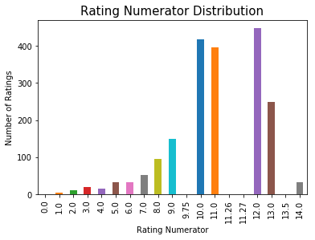

```python
df['rating_numerator'].value_counts().sort_index().plot('bar')
plt.title ('Rating Numerator Distribution', size=15)
plt.xlabel('Rating Numerator')
plt.ylabel('Number of Ratings')
plt.plot();
```

Most of the dogs get rating_numerator in between 10-13

There is very few dogs even 1 or 2 with rating 0 and numerator rating as float

### What are the 10 most frequent dog names?

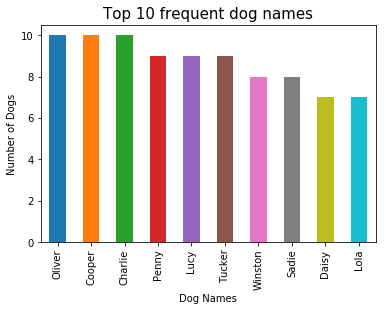

```python
df['name'].value_counts()[0:10].sort_values(ascending=False).plot(kind = 'bar')
plt.ylabel('Number of Dogs')
plt.title('Top 10 frequent dog names', size=15)
plt.xlabel('Dog Names')
plt.plot();
```

Also, check the count below:

```python
#Top 10 frequent dog names
df['name'].value_counts()[0:10].sort_values(ascending=False)
```

```
Oliver     10
Cooper     10
Charlie    10
Penny       9
Lucy        9
Tucker      9
Winston     8
Sadie       8
Daisy       7
Lola        7
Name: name, dtype: int64
```

### What are the 10 most frequent predicted dog breeds?

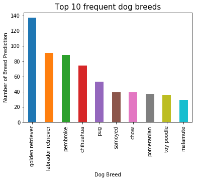

```python
df['pred_breed'].value_counts()[0:10].sort_values(ascending=False).plot(kind = 'bar')
plt.ylabel('Number of Breed Prediction')
plt.title('Top 10 frequent dog breeds', size=15)
plt.xlabel('Dog Breed')
plt.plot();
```

```python
#Top 10 frequent dog breeds
df['pred_breed'].value_counts()[0:10].sort_values(ascending=False)
```

```
golden retriever      137
labrador retriever     91
pembroke               88
chihuahua              74
pug                    53
samoyed                39
chow                   39
pomeranian             37
toy poodle             36
malamute               29
Name: pred_breed, dtype: int64
```